# Sprawozdanie 3

Maria Bul, Adrian Pilarski

2024-01-23

# Polecenie

W pliku ‘banknotes.csv’ znadjują się dane opisujące obrazy banknotów. Dane powstały poprzez transformatę falową (wavelett transform) zastosowaną do obrazów w skali szarości rozmiaru 400x400 pikseli. Po zastosowaniu transformaty wyliczono cztery charakterystyki liczbowe obrazu - wariancję, skośność, kurtozę oraz entropię.

Za pomocą modelu regresji logistycznej sprawdź czy za pomocą tej metody jesteśmy w stanie dobrze odróżnić banknoty prawdziwe od fałszywych.

- Zbuduj i zinterpretuj model regresji logistycznej (w razie otrzymania ostrzeżenia od software’u stosownie należy je skomentować, ale się nim nie przejmować).
- Zbadaj i zinterpretuj jego charakterystyki liczbowe za pomocą macierzy pomyłek.
- Wyrysuj krzywą ROC otrzymanego modelu i podaj AUC. Zinterpretuj otrzymane wyniki.
- (dodatkowo) Zastosuj redukcję wymiarów algorytmem PCA, tak aby wybrane składowe wyjaśniały ~90% wariancji w danych.
- (dodatkowo) Zbuduj model regresji logistycznej na wybranych powyżej składowych głównych i porównaj go z oryginalnym.

```r
library(tidyverse)
library(caret)
library(ggfortify)
```

```r
library(readr)
library(ggplot2)
```

Zacznijmy od wczytania naszych danych i zerknięcia na ich podsumowanie

```r
bank <- readr::read_csv('banknote.csv', col_names = FALSE)
head(bank)
```

```
## # A tibble: 6 × 5
##      X1    X2    X3     X4    X5
##   <dbl> <dbl> <dbl>  <dbl> <dbl>
## 1 3.62   8.67 -2.81 -0.447     0
## 2 4.55   8.17 -2.46 -1.46      0
## 3 3.87  -2.64  1.92  0.106     0
## 4 3.46   9.52 -4.01 -3.59      0
## 5 0.329 -4.46  4.57 -0.989     0
## 6 4.37   9.67 -3.96 -3.16      0
```

```r
summary(bank)
```

```
##        X1                X2                X3                X4
##  Min.   :-7.0421   Min.   :-13.773   Min.   :-5.2861   Min.   :-8.5482
##  1st Qu.:-1.7730   1st Qu.: -1.708   1st Qu.:-1.5750   1st Qu.:-2.4135
##  Median : 0.4962   Median :  2.320   Median : 0.6166   Median :-0.5867
##  Mean   : 0.4337   Mean   :  1.922   Mean   : 1.3976   Mean   :-1.1917
##  3rd Qu.: 2.8215   3rd Qu.:  6.815   3rd Qu.: 3.1793   3rd Qu.: 0.3948
##  Max.   : 6.8248   Max.   : 12.952   Max.   :17.9274   Max.   : 2.4495
##        X5
##  Min.   :0.0000
##  1st Qu.:0.0000
##  Median :0.0000
##  Mean   :0.4446
##  3rd Qu.:1.0000
##  Max.   :1.0000
```

Możemy zauważyć, że średnia zmiennej celu $X5$ wynosi około $0.446$, co sugeruje, że mamy nieco więcej obserwacji klasy 0 (fałszywe banknoty) niż klasy 1 (prawdziwe banknoty).

Patrząc na kwartyle, możemy zobaczyć, że zmienne różnią się w swoim rozkładzie. To również może wpływać na efektywność modelu, a zastosowanie technik standaryzacji może pomóc w równoważeniu wpływu różnych zmiennych.

Wiemy oczywiście, że zmienną zależną w naszym modelu jest zmienna $X5$, mówiąca o tym czy banknot jest prawdziwy czy nie, natomiast wszystkie pozostałe zmienne to predyktory.

Narysujmy sobie histogramy zmiennych numerycznych

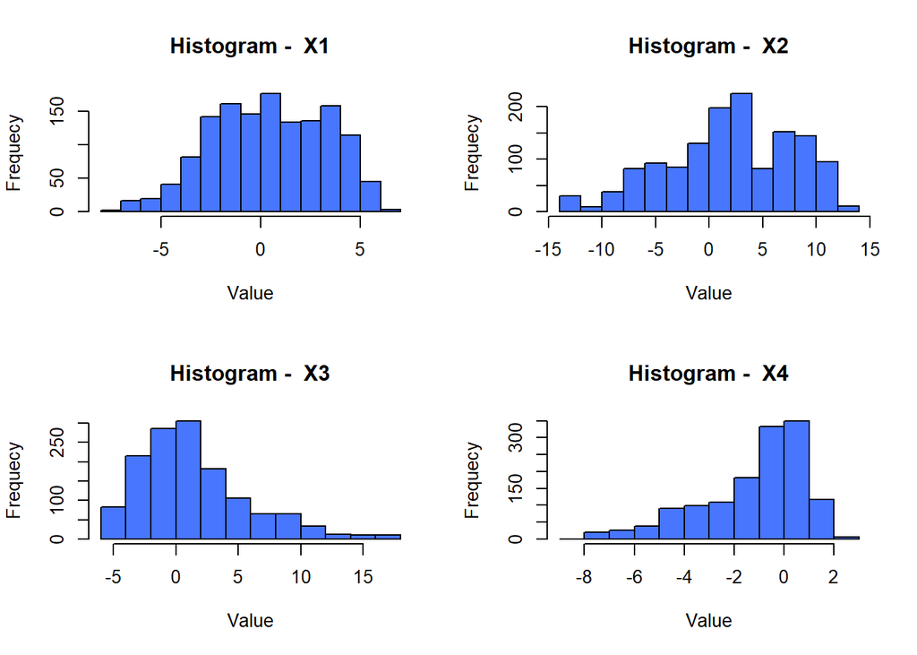

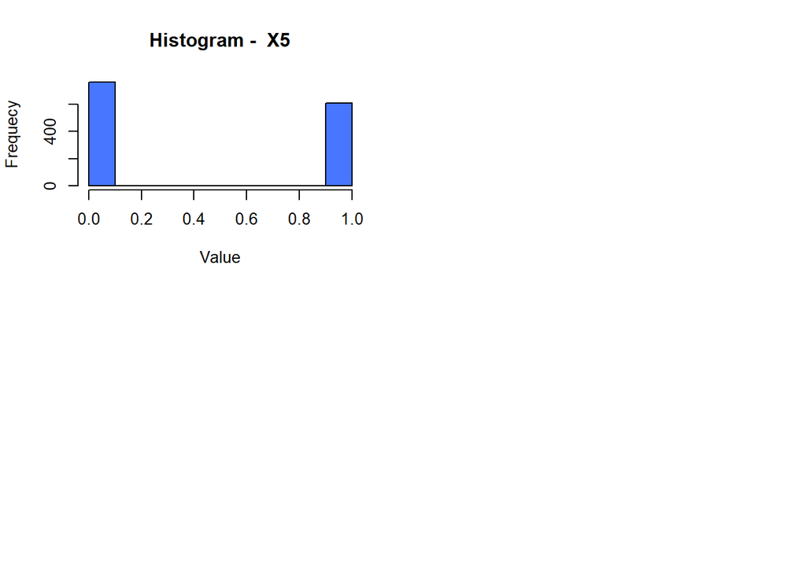

```r
bank_numeric<-bank %>% select_if(is.numeric)

par(mfrow = c(2,2))

for (i in 1:ncol(bank_numeric)){
  column_name<-colnames(bank_numeric)[i]
  hist(bank_numeric[[column_name]],
       main = paste("Histogram - ", column_name),
       xlab = "Value", ylab = "Frequecy", col = "royalblue1")
}
```

Zerknijmy jeszcze na wykresy pudełkowe

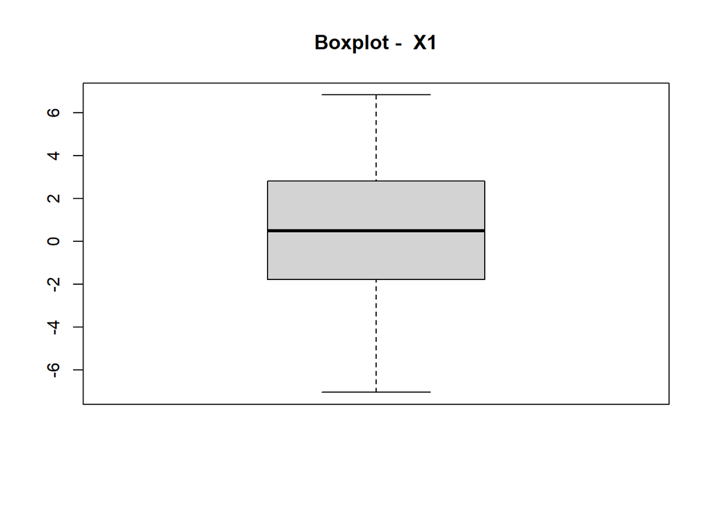

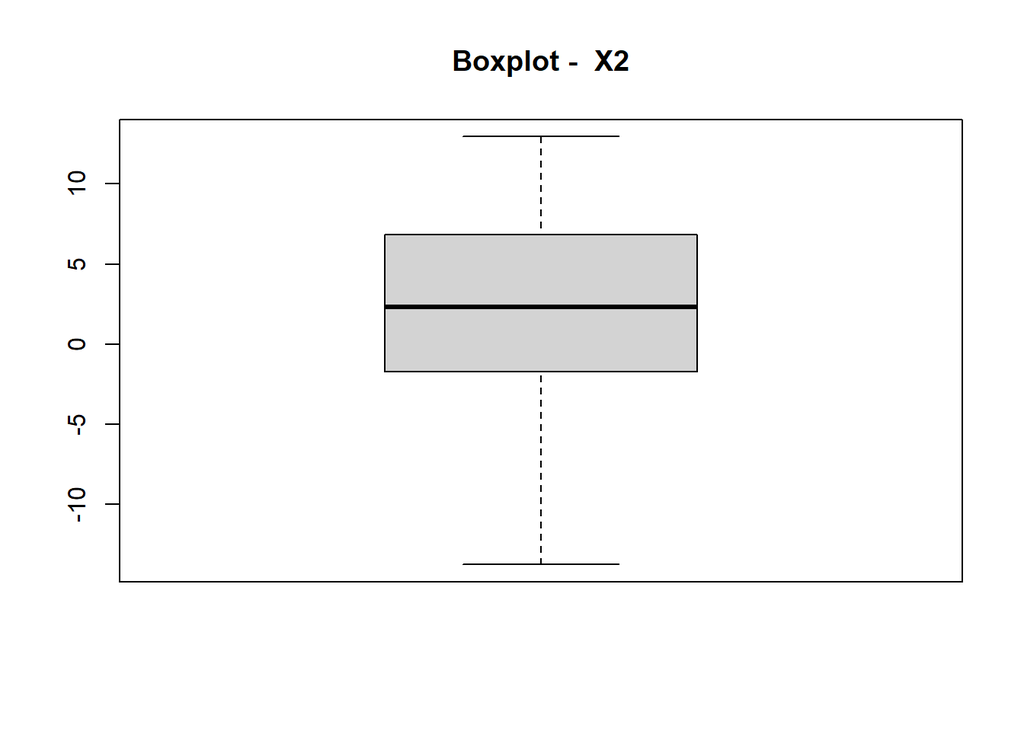

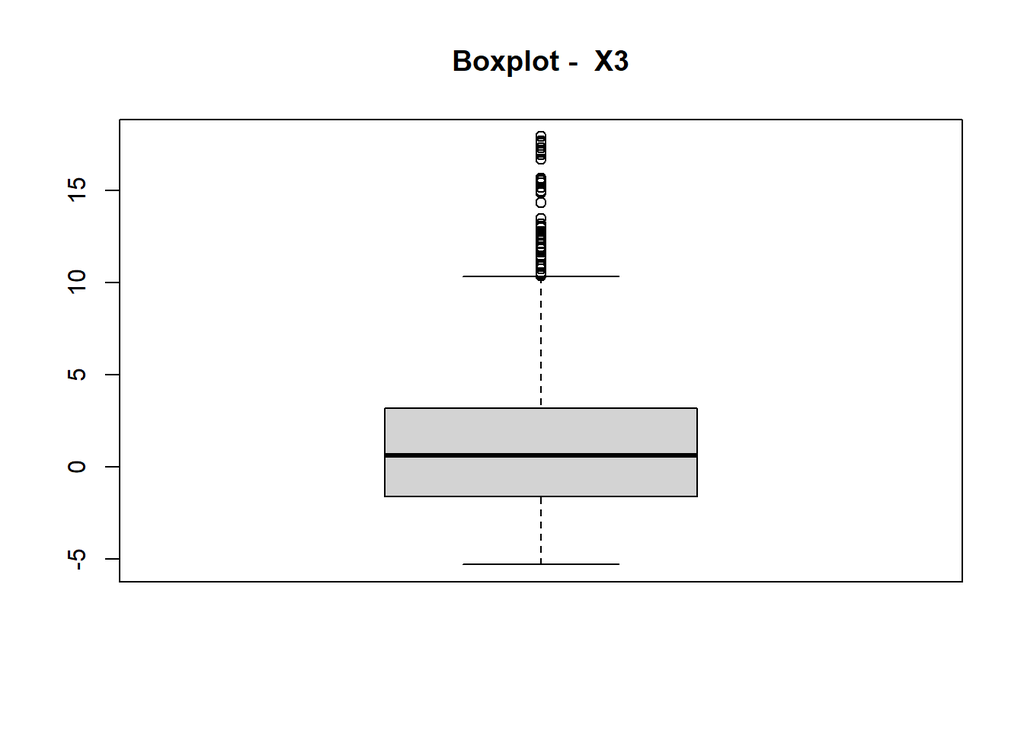

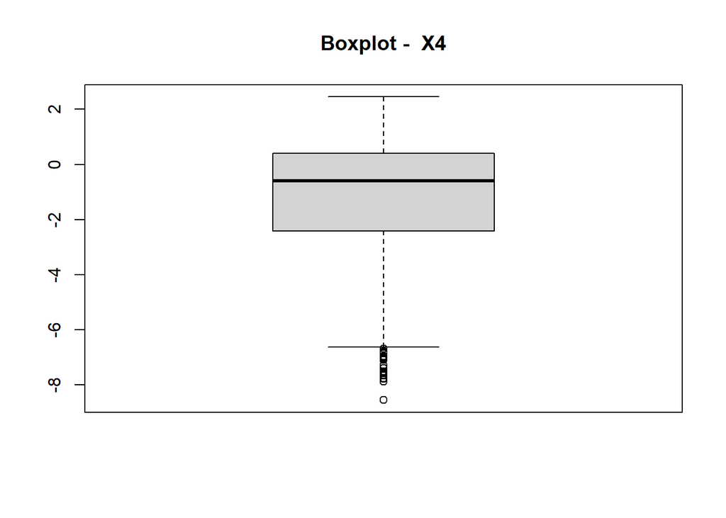

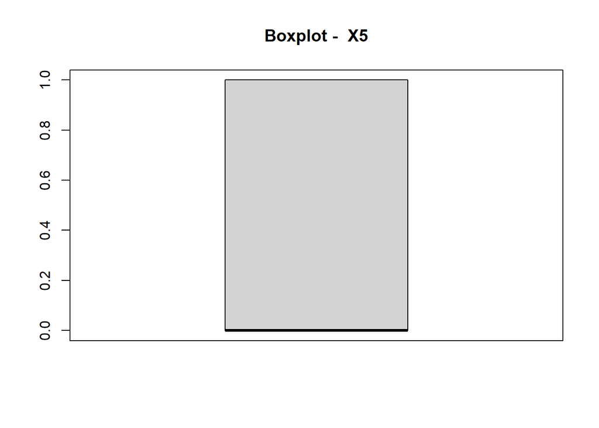

```r
for (i in 1:ncol(bank_numeric)){
  column_name<-colnames(bank_numeric)[i]
  boxplot(bank_numeric[[column_name]],
       main = paste("Boxplot - ", column_name))
}
```

Widzimy że dla zmiennych $X3$, oraz $X4$ występują wartości odstające, narazie je zostawimy. Mogą one zawierać istotne informacje.

Popatrzmy jeszcze na to jak rozkłada się nasza zmienna $X5$.

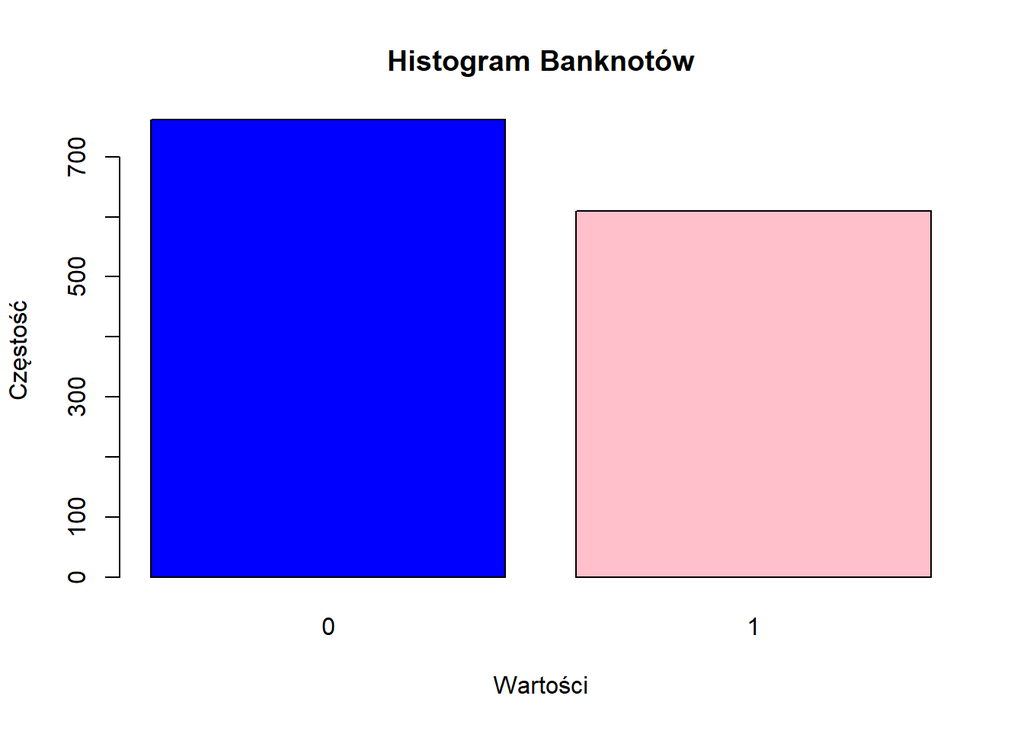

```r
frequency <- table(bank$X5)

barplot(frequency,
        xlab = "Wartości",
        ylab = "Częstość",
        main = "Histogram Banknotów",
        col = c("blue", "pink"),
        names.arg = c("0", "1"))
```

Widzimy, że dane są zbilansowane (jest mniej więcej po połowie)

# Zbiór treningowy i testowy

Teraz podzielimy sobie nasze dane na zbiór treningowy i testowy

```r
split_index <- createDataPartition(bank$X5, p = 0.8, list = FALSE)
train_data <- bank[split_index, ]
test_data <- bank[-split_index, ]
```

Zobaczmy jak podzielił się nasz zbiór

```r
nrow(train_data)
```

```
## [1] 1098
```

```r
nrow(test_data)
```

```
## [1] 274
```

Teraz, kiedy mamy podzielone dane, możemy kontynuować z budową modelu regresji logistycznej na zbiorze treningowym.

Zobaczmy jeszcze jak wygląda podsumowanie naszych danych treningowych.

```r
summary(train_data)
```

```
##        X1                X2                X3                X4
##  Min.   :-7.0421   Min.   :-13.773   Min.   :-5.2613   Min.   :-8.5482
##  1st Qu.:-1.7672   1st Qu.: -1.430   1st Qu.:-1.6105   1st Qu.:-2.4661
##  Median : 0.3798   Median :  2.472   Median : 0.5387   Median :-0.5983
##  Mean   : 0.4031   Mean   :  1.968   Mean   : 1.3752   Mean   :-1.2031
##  3rd Qu.: 2.7723   3rd Qu.:  6.809   3rd Qu.: 3.1839   3rd Qu.: 0.4139
##  Max.   : 6.8248   Max.   : 12.625   Max.   :17.9274   Max.   : 2.4495
##        X5
##  Min.   :0.0000
##  1st Qu.:0.0000
##  Median :0.0000
##  Mean   :0.4517
##  3rd Qu.:1.0000
##  Max.   :1.0000
```

Widzimy jak wyglądają nasze dane, przejdźmy do pierwszego modelu regresji logistycznej.

```r
table(bank$X5)
```

```
##
##   0   1
## 762 610
```

Widzimy, że mamy $762$ banknotów, które nie są prawdziwe oraz $610$ banknotów prawdziwych.

Sprawdźmy jeszcze jak wygląda to w naszym zbiorze treningowym.

```r
table(train_data$X5)
```

```
##
##   0   1
## 602 496
```